# Презентация по лабораторной работе №10

Дисциплина: Архитектура компьютеров и операционные системы

Гусев Степан Андреевич

1032242444@rudn.ru

Российский университет дружбы народов

2026-04-04

# Информация

**Презентация по лабораторной работе №10**

**Автор:** Гусев Степан Андреевич

**Преподаватель:** Кулябов Дмитрий Сергеевич, д.ф.-м.н., профессор кафедры теории вероятностей и кибербезопасности

Российский университет дружбы народов

## Докладчик

- Гусев Степан Андреевич
- Студент программы “Бизнес-информатика”
- Российский университет дружбы народов им. П. Лумумбы
- 1032242444@rudn.ru
- https://github.com/stepagusev

## Цель

Познакомиться с операционной системой Linux. Получить практические навыки работы с редактором vi, установленным по умолчанию практически во всех дистрибутивах.

## Задание

1. Ознакомиться с теоретическим материалом.
2. Ознакомиться с редактором vi.
3. Выполнить упражнения, используя команды vi.

# Выполнение лабораторной работы

## Создание нового файла с использованием vi

Создал новую директорию и перешёл.

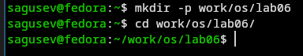

Рисунок 1: Работа с директорией

## Создание нового файла с использованием vi

Вызвал vi и создал файл hello.sh.

## Создание нового файла с использованием vi

Нажал клавишу i и ввёл нужный текст.

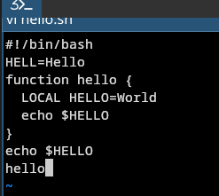

Рисунок 3: Ввод текста

## Создание нового файла с использованием vi

Нажал Ecs, :, ввёл wq, вышел из vi, сохранив изменения.

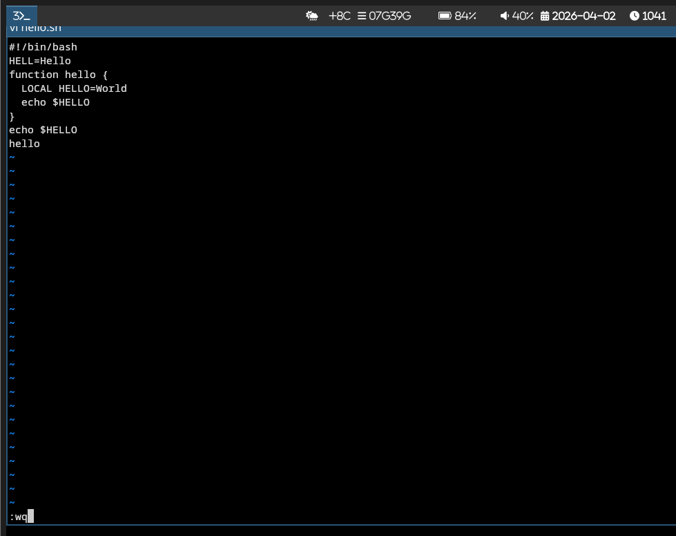

Рисунок 4: Выход из vi

## Создание нового файла с использованием vi

Сделал файл исполняемым с помощью chmod.

## Редактирование существующего файла

Открыл в vi файл hello.sh.

## Редактирование существующего файла

Перешёл в режим вставки и заменил HELL на HELLO.

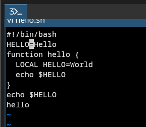

Рисунок 7: Редактирование файла

## Редактирование существующего файла

Стёр слово LOCAL в 4 строке.

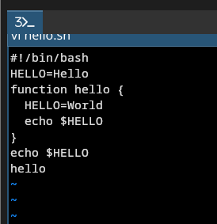

Рисунок 8: Редактирование файла

## Редактирование существующего файла

Написал в 4 строке local.

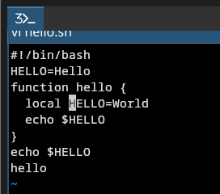

Рисунок 9: Редактирование файла

## Редактирование существующего файла

Добавил echo $HELLO в конец файла.

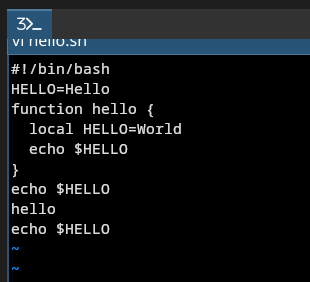

Рисунок 10: Редактирование файла

## Редактирование существующего файла

Удалил последнюю строку.

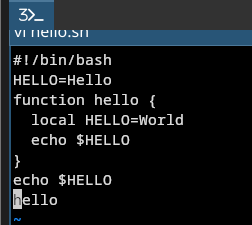

Рисунок 11: Редактирование файла

## Редактирование существующего файла

Отменил последнее действие нажав u.

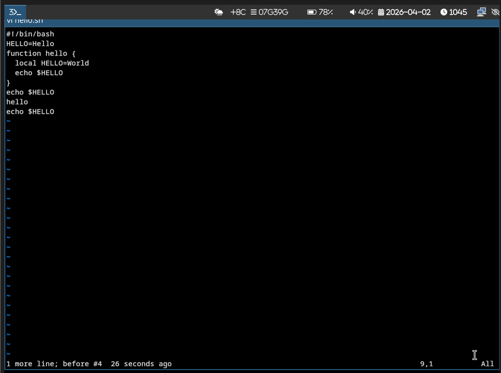

Рисунок 12: Отмена действия

## Редактирование существующего файла

Нажал :, ввёл wq, вышел из vi, сохранив изменения.

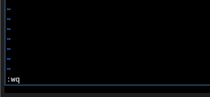

Рисунок 13: Выход из vi

# Выводы

## Выводы

Я получил практические навыки работы с редактором vi.